# Precificação de Títulos de Dívida

Ross et al. (2022), capítulo 07

Marcelo S. Perlin

EA-UFRGS

21/09/2026

# Precificação de dívidas

## Introdução

> Títulos de dívida são nada mais que fluxos de caixa ao longo do tempo.
- Conceitos de matemática financeira (TIR, VP, VF) são aplicáveis
- Componentes de uma dívida negociável no mercado:
  - Componente fixo: Maturidade e cronograma de pagamentos
  - Componentes variáveis: risco e remuneração (yield/retorno)

Todos os cálculos disponíveis no [GSheet](https://docs.google.com/spreadsheets/d/12pu98nVWtEQJaEL03m-42M5HfTPTAPn6L-cEsuZU9qc/edit?usp=sharing).

## Representação de um Título de Renda Fixa com cupons

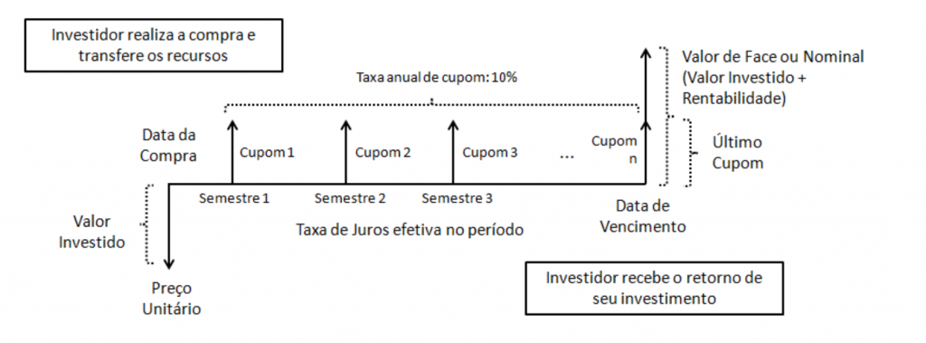

Exemplo de título de dívida com cupom [(fonte)](https://www.tesourodireto.com.br/titulos/tipos-de-tesouro.htm)

## Precificação de um título de dívida

$$VP = \sum ^T _{i=1} \frac{C}{(1+r)^i} + \frac{F}{(1+r)^T}$$
onde:

$VP$ - Valor do título hoje (tempo 0)

$T$ - Número de anos (ou intervalos de tempo)

$C$ - Cupom pago por intervalo

$r$ - Taxa de juros

$F$ - Valor de face (pago na data de vencimento da dívida)

# Marcação a Mercado

## O que é a marcação a mercado?

> “**Professor, comprei uma LTN 2025 em fevereiro de 2020. Fui ver o valor de resgate hoje e estou com prejuízo. O que aconteceu?“**.

### LTN 010125: título pré-fixado sem pagamento de cupom

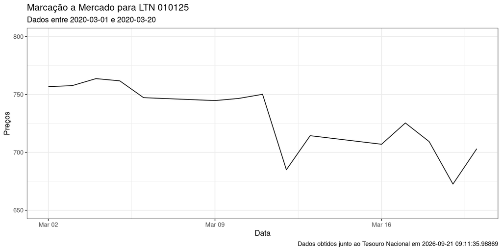

## A história termina bem..

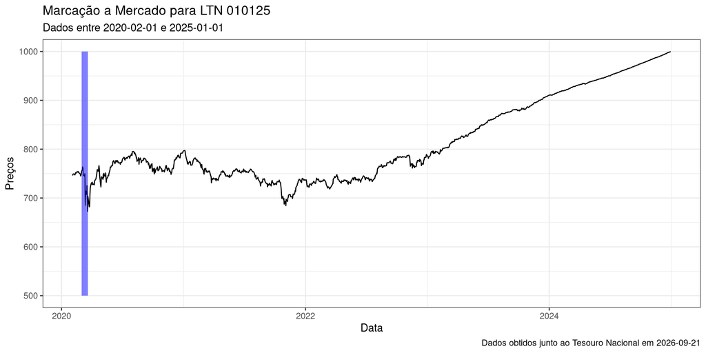

## Explicação

> Marcação a Mercado é a *precificação diária* do seu investimento, isto é, a atualização frequente do preço de um ativo financeiro para o valor que o mercado está disposto a pagar.
- Os preços no Tesouro Direto variam pois:
  - Os juros (e preços) oferecidos no mercado refletem uma expectativa geral dos participantes
  - Investidores possuem diferentes opiniões sobre risco
    - Caso eles achem que a remuneração oferecida em um título de dívida está alta, eles compram o título e puxam o preço para cima
    - Quando o preço aumenta, a remuneração oferecida diminui

## Retorno até vencimento (YTM) ou Taxa Interna de Retorno (TIR)

> A YTM (*Yield To Maturity*) representa o juros implícito do contrato. Em outras palavras, é a taxa de juros que faz com que o valor presente do contrato seja igual ao valor do título no mercado.
- Formas de cálculo
  - HP12C
  - Manual (tentativa e erro)
  - Gsheets

[Vai GSheets](https://docs.google.com/spreadsheets/d/12pu98nVWtEQJaEL03m-42M5HfTPTAPn6L-cEsuZU9qc/edit?usp=sharing)

## Exemplo do Tesouro Direto

Preços e Yields (TIR) de Títulos Prefixados

Dados Retirados em 2026-09-21

| Data de Referência | Código do Título | Preço de Compra | Yield de Compra |
| --- | --- | --- | --- |
| 2026-09-18 | LTN 010127 | 965.34 | 13.54% |

## Efeito dos Juros e Maturidades sobre Preços

> Quanto maior é o vencimento de uma dívida, mais sensível o preço desta a mudanças na taxa de juros da economia (SELIC)

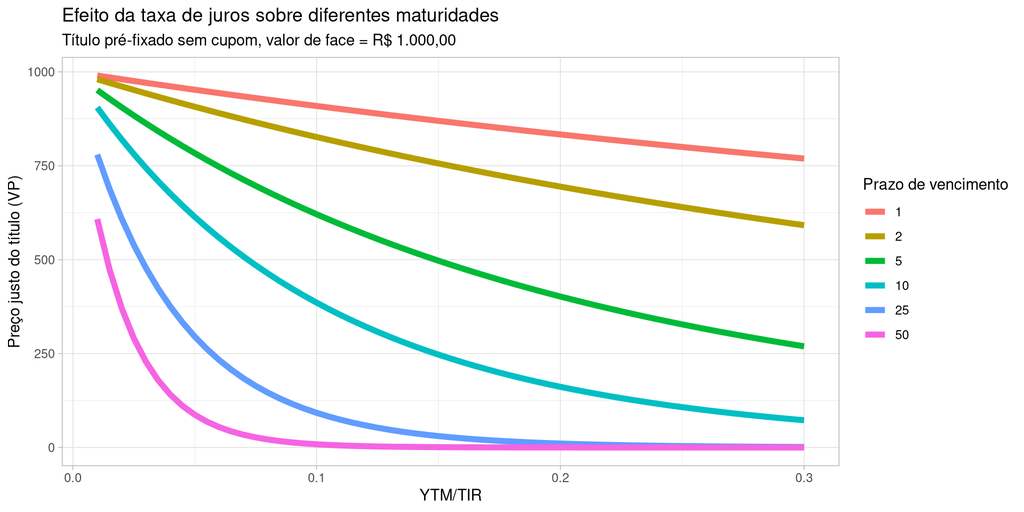

- A medida que os juros mudam (eixo x), os títulos com vencimento maior são mais afetados e apresentam maior variação de preço

# O impacto do Risco

## Introdução

> Quanto maior o risco de calote de uma dívida, maior deve ser o yield
- Risco de Default = Risco de calote (devedor não pagar)
- O risco é difícil de medir e está intrinsecamente relacionado ao produto e estrutura da dívida

## Taxa de mercado para aquisição de veículos

10 **Maiores** Taxas de Financiamento | Automóveis (Pessoa Física)

Dados de referência: 01/07/2026

| Instituição | Juros_AA |
| --- | --- |
| OMNI SA CFI | 50.36% |
| SIMPALA S.A. CFI | 47.33% |
| BCO DAYCOVAL S.A | 46.60% |
| FINAMAX S.A. CFI | 46.12% |
| BANCO PAN | 41.35% |
| BCO YAMAHA MOTOR S.A. | 35.63% |
| AGORACRED S/A SCFI | 35.59% |
| BCO HONDA S.A. | 33.01% |
| BCO VOTORANTIM S.A. | 31.58% |
| ITAÚ UNIBANCO HOLDING S.A. | 28.38% |

10 **Menores** Taxas de Financiamento | Automóveis (Pessoa Física)

Dados de referência: 01/07/2026

| Instituição | Juros_AA |
| --- | --- |
| BCO MERCEDES-BENZ S.A. | 8.45% |
| BMW SA CFI | 10.46% |
| BCO RCI BRASIL S.A. | 11.89% |
| BCO DA AMAZONIA S.A. | 14.40% |
| BANCO HYUNDAI CAPITAL BRASIL | 16.04% |
| BANCO CNH INDUSTRIAL CAPITAL S.A | 17.21% |
| BCO GM S.A. | 18.92% |
| SCANIA BCO S.A. | 19.14% |
| STELLANTIS FINANCIAMENTOS CFI | 19.76% |
| BANCO TRATON BRASIL S.A. | 20.19% |

Fonte: [Banco Central](https://www.bcb.gov.br/estatisticas/reporttxjuros?codigoSegmento=1&codigoModalidade=401101) (01/07/2026)

Média de todas as taxas: 25,84% ao ano

## Taxas de mercado para financiamento imobiliário

Taxas de Financiamento | Imóveis (Pessoa Física)

Dados obtidos em 2026-09-21 09:11:50.996621 * Juros da CAIXA é subsidiado pelo governo

| MODALIDADE | Instituição | Juros_AA |
| --- | --- | --- |
| FINANCIAMENTO IMOBILIÁRIO COM TAXAS REGULADAS - PREFIXADO | CAIXA ECONOMICA FEDERAL | 10.94% |
| FINANCIAMENTO IMOBILIÁRIO COM TAXAS DE MERCADO - PREFIXADO | BCO SANTANDER (BRASIL) S.A. | 15.12% |
| FINANCIAMENTO IMOBILIÁRIO COM TAXAS DE MERCADO - PREFIXADO | APE POUPEX | 16.95% |

Fonte: [Banco Central](https://www.bcb.gov.br/estatisticas/reporttxjurosmensal?codigoSegmento=1&codigoModalidade=903201) (21/09/2026)

Média de todas as taxas: 14,34% ao ano

# Inflação

## Efeitos da Inflação

> Inflação é o aumento contínuo e generalizado dos preços de bens e serviços em uma economia durante um período de tempo. Ela significa que, com a mesma quantidade de dinheiro, você pode comprar menos produtos do que antes.
- Causas da inflação
  - Aumento na oferta de moeda
  - Aumento de demanda por produtos, sem aumento na oferta
  - Efeito antecipatório dos agentes econômicos
- Efeito degradante sobre a remuneração líquida de um título de dívida

## Inflação no Brasil (IPCA)

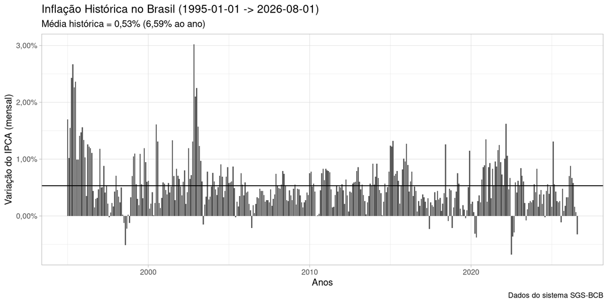

## Inflação (IPCA) e Taxas de Juros (SELIC)

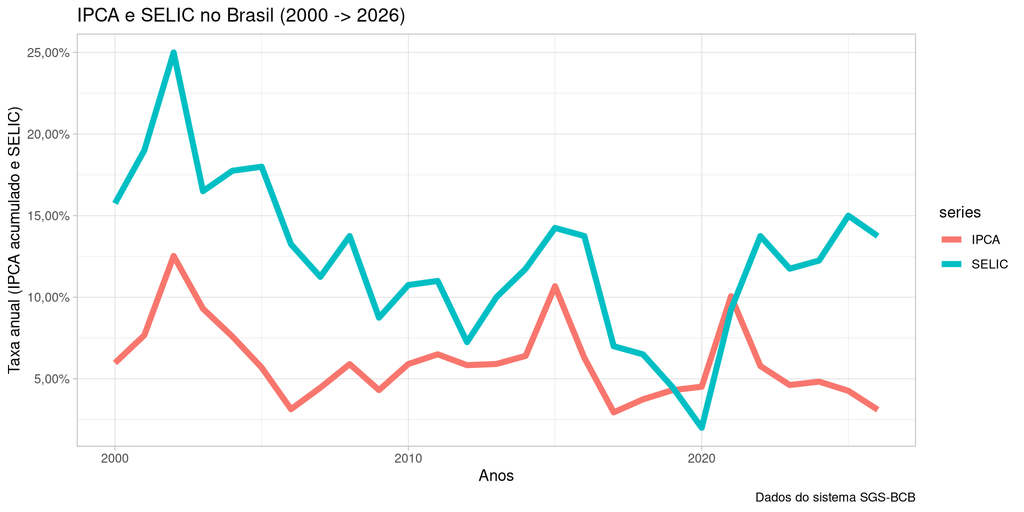

## Efeito da inflação sobre o poder de compra

**Fórmula de Fisher (Fisher and Barber 1907)**

$$(1+R) = (1+r)(1+h)$$

onde:

$R$ - Retorno nominal

$h$ - Valor percentual da inflação

$r$ - Retorno real

## Exemplo 01

> Um determinado título rendeu 10,00% ao longo de um ano, enquanto a inflação no período foi de 6,00%. Calcule a taxa real de retorno anual.

$$r = \frac{1+R}{1+h} - 1 = \frac{1+0.1}{1+0.06} - 1 = 0.0377358$$
A taxa real de retorno foi de 3,77% ao ano.

## Exemplo 02 - A performance do índice Ibovespa

> Entre 02/01/1995 e 18/09/2026 (31 anos), o índice ibovespa rendeu um total de 4.206,65%, equivalente a 12,59% ao ano. Para o mesmo período, o principal índice de inflação (IPCA) teve uma variação total de 638,42% (6,50% ao ano).

Dadas estas informações, qual o retorno real total do índice ibovespa e o retorno real anual?

$$r_{total} = \frac{1+42.0664962}{1+6.3842114} - 1 = \text{483,22%}$$

$$r_{aa} = \frac{1+R}{1+h} - 1 = \frac{1+0.1258978}{1+0.0650355} - 1 = \text{5,71%}$$

# Estrutura a Termo das Taxas de Juros Nominais

## Introdução

> A estrutura a termo demonstra o valor do dinheiro em diferentes prazos de vencimento Maturidades maiores usualmente oferecem maiores remunerações

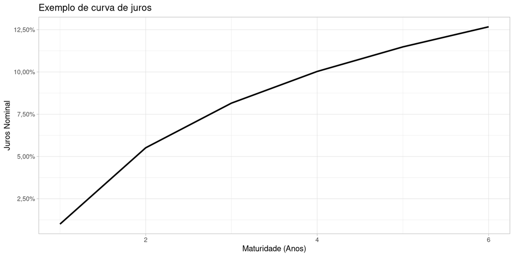

- Quanto maior o tempo da dívida, maior o risco e maior os juros cobrados em uma dívida
- Quanto maior o tempo, menos pessoas dispostas a alocar recurso no investimento

## A dinâmica da Estrutura a Termo no Brasil

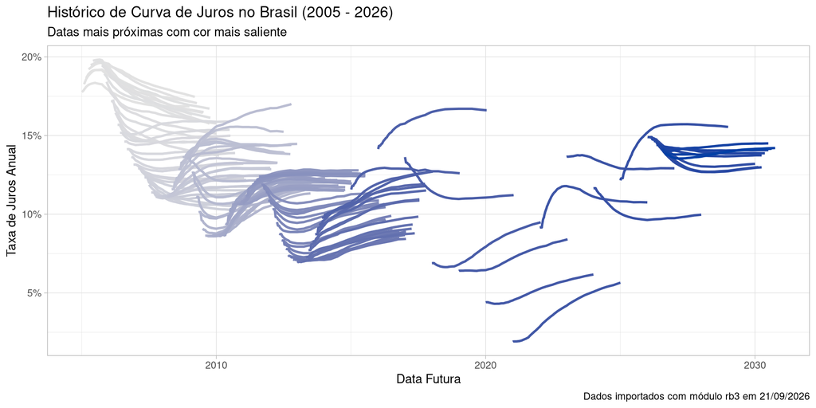

## Referências

Fisher, Irving, and William Joseph Barber. 1907. *The Rate of Interest*. Garland Pub.

Ross, Stephen, Randolph Westerfield, Bradford Jordan, et al. 2022. *Fundamentos de Administração Financeira*. Bookman Editora.